# 3. Posterior predictive and prior predictive sampling

Frank Edwards

## Sampling from the posterior

- We use Bayesian methods to *approximate* the posterior distribution
- We can then sample parameters from the estimated posterior to learn about parameters or to simulate predictions
- We can plot densities, directly sample *credible intervals*, compare differences in means, all without relying on a theoretical *sampling distribution*, like we do with frequentist methods
- We can even simulate *new* data from the posterior

## Quadratic approximation

1. Assume our posterior is approximately Normal (often reasonable)
2. Find the mode
3. Estimate curvature of the log posterior with a parabola
4. Use the resulting Gaussian distribution for inference
5. With enough data: $\textsf{quap} \rightarrow \textsf{MLE}$

## Quadrating approximation logic

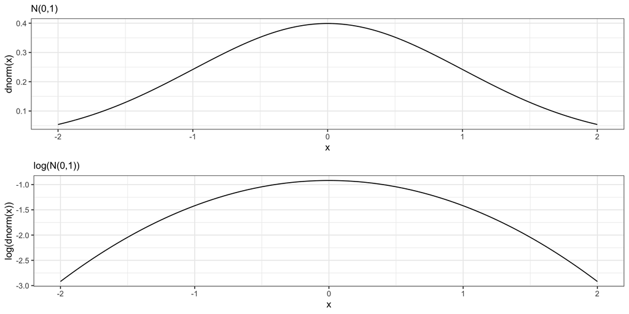

## Using quadratic approximation in R

9 draws from the bag of red and green marbles, we observe 6 green.

```r
### First, define the data as a list() object
### let's treat 1 as green, 0 as red
dat<-list(G = 6, R = 3)
```

## Using quadratic approximation in R

```r
## Specify the prior and likelihood in alist() object
formula_list<-alist(
  # likelihood
  G ~ dbinom(R+G, p),
  # prior
  p ~ dunif(0,1)
)
```

## Using quadratic approximation in R

```r
model1<-quap(
  formula_list,
  data = dat
)
```

## Using quadratic approximation in R

```r
# summarize the distribution using summary() or precis()
summary(model1)
```

```
       mean        sd      5.5%     94.5%
p 0.6666667 0.1571338 0.4155365 0.9177968
```

## Extract posterior samples

```r
post_samples<-extract.samples(model1, n=10000)
```

## Visualize

```r
p1<-ggplot(post_samples, aes(y = p, x = 1:nrow(post_samples))) +
  geom_point(alpha = 0.1)
p2<-ggplot(post_samples, aes(x = p)) +
  geom_density()
### grid.arrange() lets us put more than one plot in a window
grid.arrange(p1, p2, ncol = 2)
```

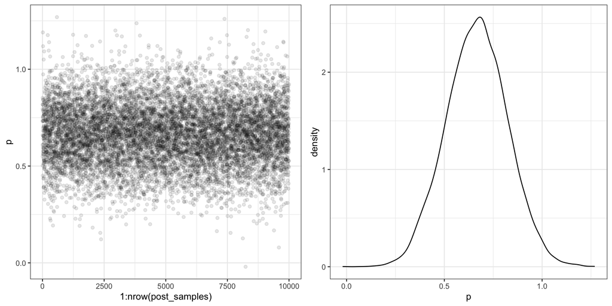

# Posterior prediction

## Simulating prediction

- We’ve learned how to describe the parameter *p* with posterior samples.
- What would happen if we re-ran the experiment?
- **Posterior predictive simulation** incorporates updated information on the parameter into predictions of new values of our observed outcome variable (W, L)

## Posterior prediction algorithm

1. Sample from the posterior distribution
2. Use these sampled posterior parameter values to sample new values from the likelihood

## Simulating from one p

```r
t <- extract.samples(model1, n=2)
t
```

```
          p
1 0.6589054
2 0.7941642
```

```r
predicted_p1 <- rbinom(n=1, size = 9, prob = t$p[1])
predicted_p1
```

```
[1] 4
```

## The distribution of predictions

```r
predicted_p1 <- rbinom(n=10000, size = 9, prob = t$p[1])
hist(predicted_p1, breaks = 0:9, main = t$p[1])
```

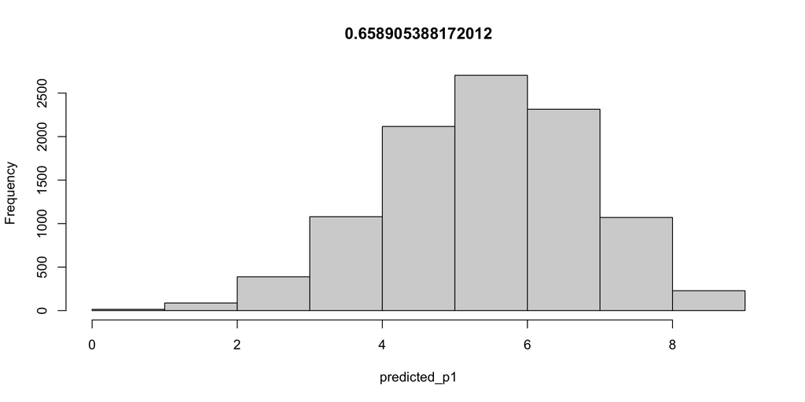

## Simulating from a different value of p

```r
predicted_p2 <- rbinom(n=10000, size = 9, prob = t$p[2])
hist(predicted_p2, breaks = 0:9, main = t$p[2])
```

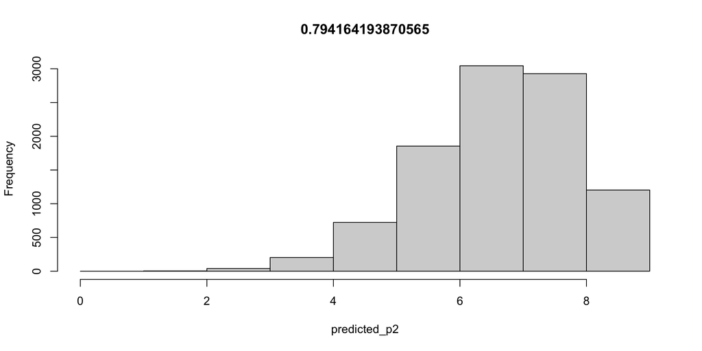

## Averaging uncertainty

```r
predicted_joint <- c(predicted_p1, predicted_p2)
hist(predicted_joint, breaks = 0:9, main = t)
```

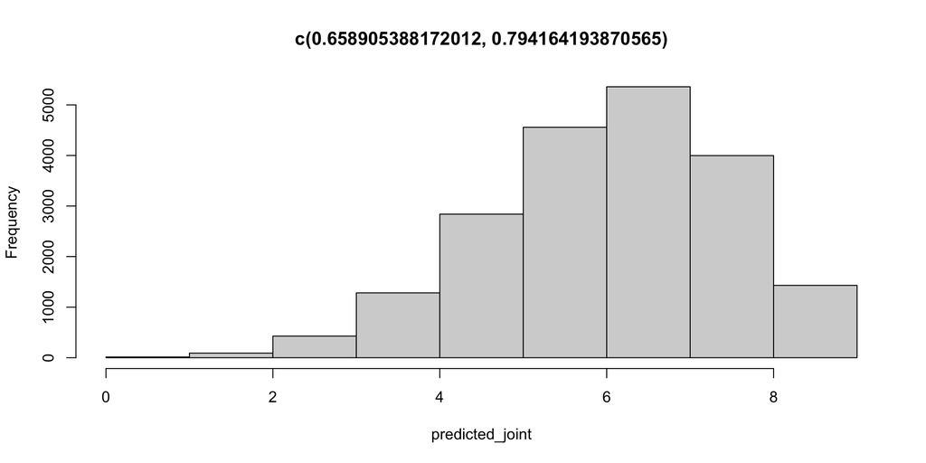

## Simulating over both values of p

```r
predicted_p_joint <- rbinom(n=20000, size = 9, prob = t$p)
hist(predicted_p_joint, breaks = 0:9, main = t)
```

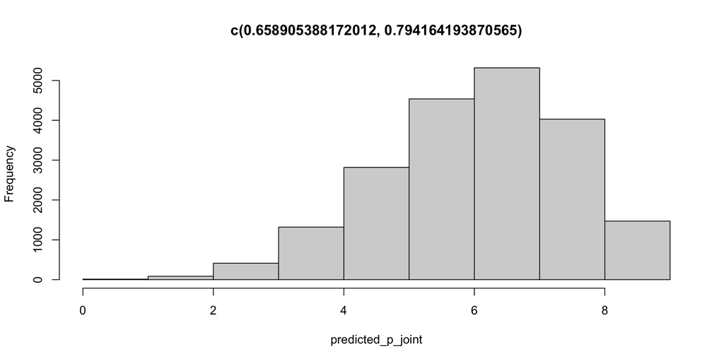

## p = posterior median

```r
p_samples <- extract.samples(model1, n = 10000)
## set p at the median of the posterior
samples<-rbinom(1e4, 9, median(p_samples$p))
hist(samples, breaks = 0:9, main = median(p_samples$p))
```

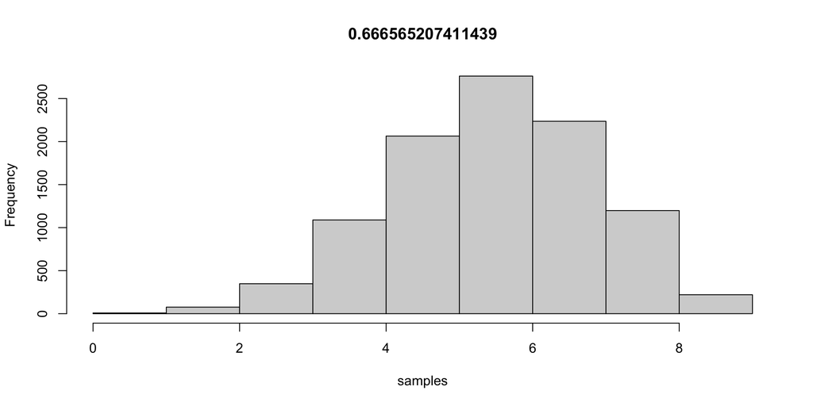

## p = posterior 5th percentile

```r
## set p at the 5th percentile of the posterior
samples<-rbinom(1e4, 9, quantile(p_samples$p, 0.05))
hist(samples, breaks = 0:9, main = quantile(p_samples$p, 0.05))
```

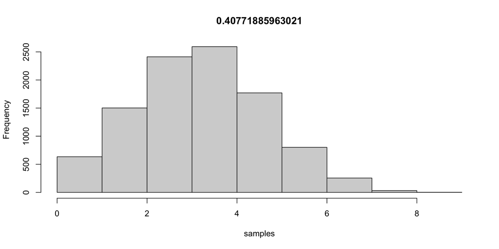

## p = posterior 95th percentile

```r
## set p at the 95th percentile of the posterior
samples<-rbinom(1e4, 9, quantile(p_samples$p, 0.95))
hist(samples, breaks = 0:9, main = quantile(p_samples$p, 0.95))
```

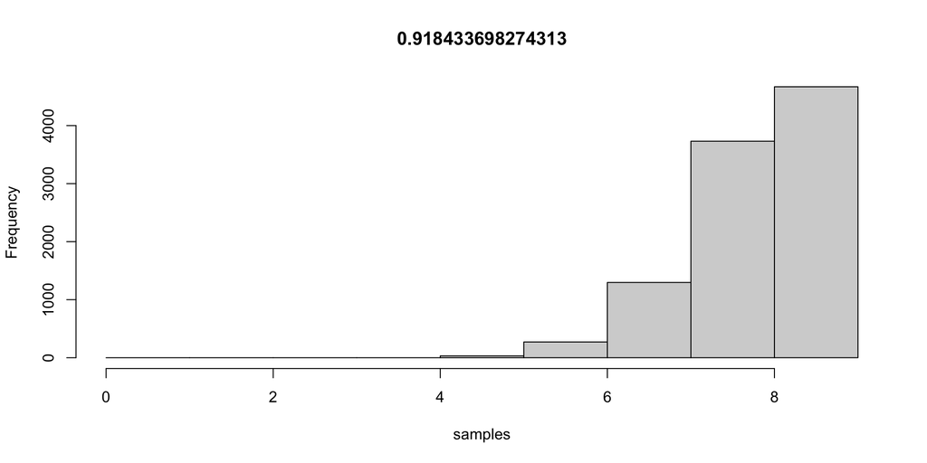

## Averaging over uncertainty in p

```r
p_samples <- extract.samples(model1, n = 10000)
hist(p_samples$p)
```

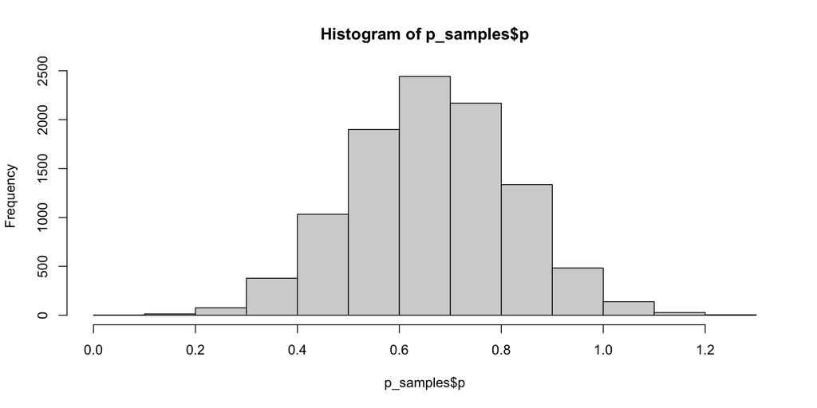

## Oops, impossible values!

```r
# correct for impossible values
p_samples <- p_samples |>
  mutate(p = case_when(
  p > 1 ~ 1,
  p < 0 ~ 0,
  .default = p
))

ggplot(p_samples, aes(x=p)) + geom_histogram()
```

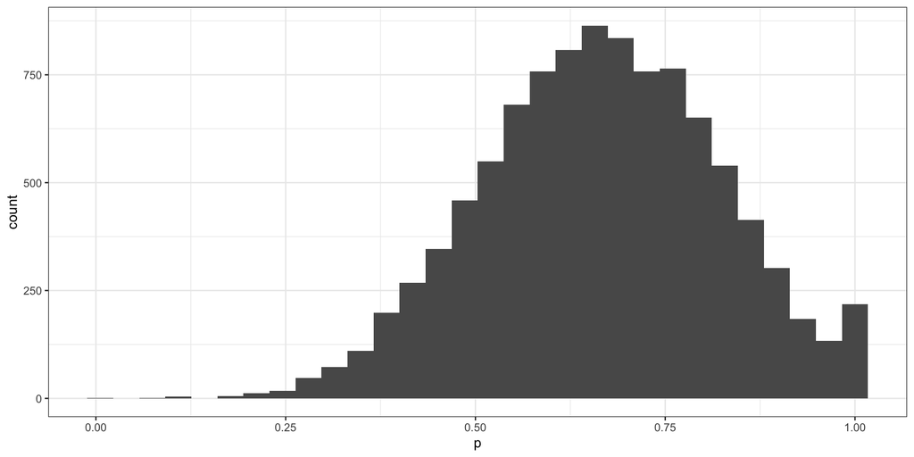

## Generate a prediction of the data for each p

```r
RG_predictions<-rbinom(1e4, size = 9, prob = p_samples$p)
## distribution of predictions of G under our posterior
head(p_samples)
```

```
          p
1 0.6243390
2 0.8218246
3 0.3954844
4 0.5735221
5 0.7429660
6 0.6236375
```

```r
head(RG_predictions)
```

```
[1] 5 8 2 4 7 5
```

## Visualize the predictions

```r
ggplot(data.frame(RG_predictions),
       aes(x = RG_predictions)) +
  geom_histogram() +
  scale_x_continuous(breaks=0:9) +
  labs(title = "Posterior predictions of G")
```

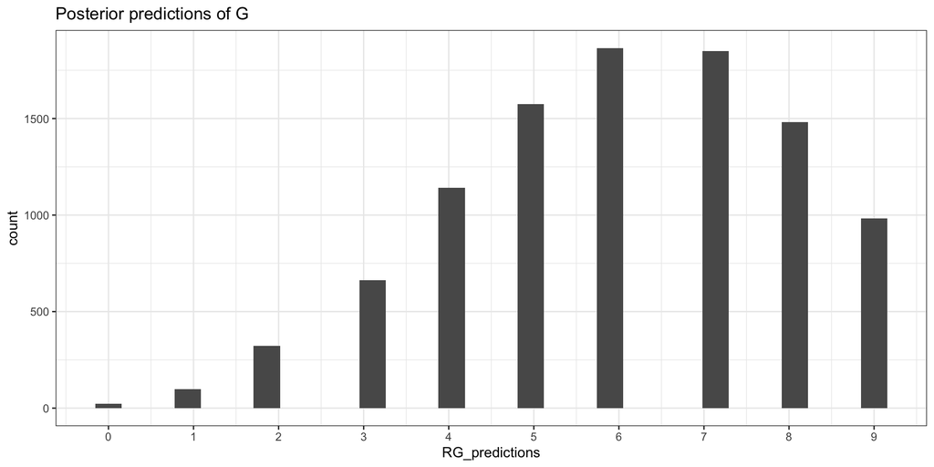

## Two kinds of uncertainty

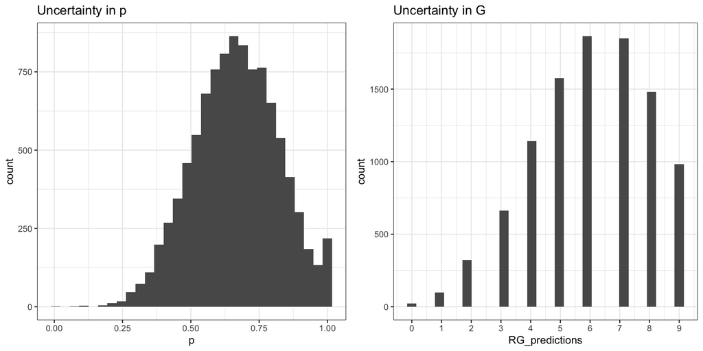

## Posterior predictions propagate ALL modeled uncertainty

```r
ggplot(data.frame(RG_predictions),
       aes(x = RG_predictions)) +
  geom_histogram() +
  scale_x_continuous(breaks=0:9) +
  labs(title = "Posterior predictions of G")
```

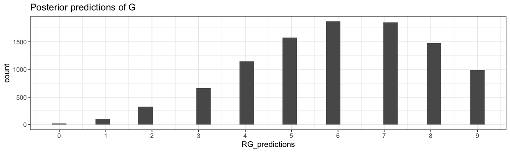

# Prior Prediction

## Prior prediction

We can also use simulation to better understand and select priors

```r
### our prior
formula_list
```

```
[[1]]
G ~ dbinom(R + G, p)

[[2]]
p ~ dunif(0, 1)
```

```r
prior_samples<-runif(1e4, 0, 1)

head(prior_samples)
```

```
[1] 0.08471689 0.46572544 0.69882652 0.36752163 0.18188801 0.62083441
```

## Visualize the prior samples

```r
ggplot(data.frame(prior_samples),
       aes(x = prior_samples)) +
  coord_cartesian(xlim = c(0, 1)) +
  geom_histogram(bins = 20)
```

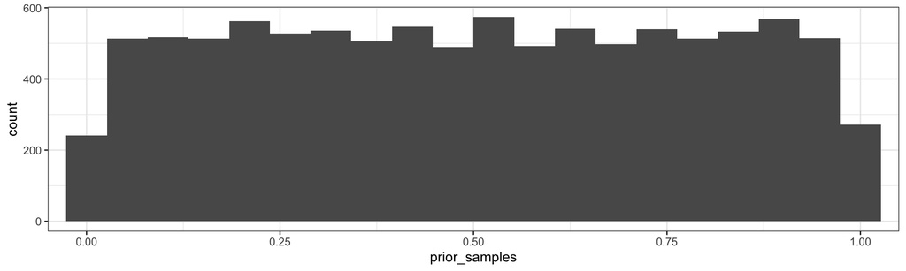

## Prior Predictive sampling

We can simulate data from this prior

```r
prior_pred <- data.frame(p = prior_samples) |>
  mutate(G = rbinom(length(prior_samples), 9, p))
head(prior_pred)
```

```
           p G
1 0.08471689 2
2 0.46572544 3
3 0.69882652 5
4 0.36752163 4
5 0.18188801 2
6 0.62083441 7
```

## Visualize

```r
ggplot(prior_pred,
       aes(x = G)) +
  geom_histogram()
```

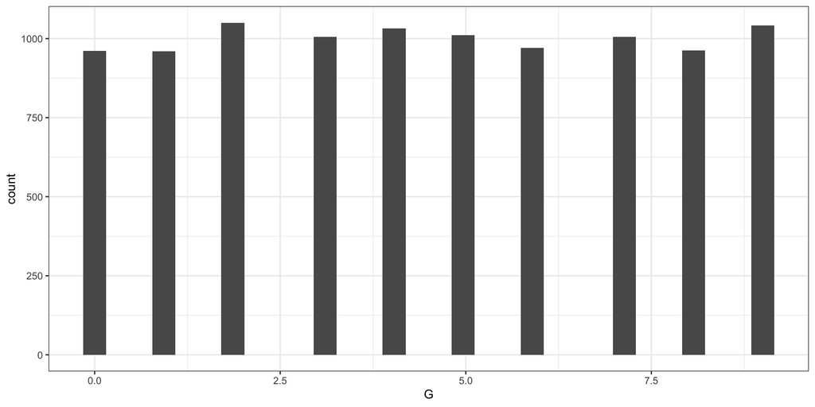

# Linear regression

## Why the Normal is so Normal

```r
n_sims <- 1000
output<-data.frame(sums = rep(NA, n_sims))
for(i in 1:1000){
  temp <- rbinom(1000, 20, 0.1)
  output$sums[i] <- sum(temp)
}

ggplot(output, aes(x = sums)) + geom_density()
```

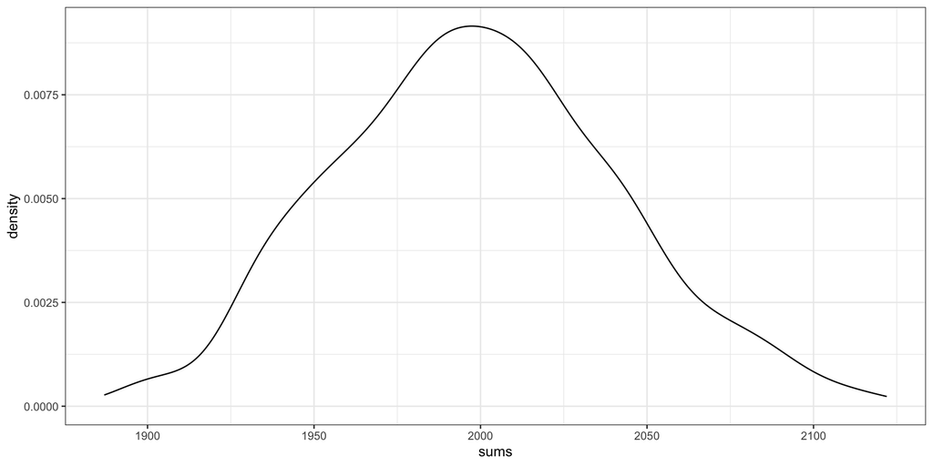

## Looks familiar…

```r
# convert to z score, x is for plotting
output <- output |>
  mutate(z = scale(sums),
         x = seq(-5, 5, length.out = n_sims))
ggplot(output,
       aes(x = z)) +
  geom_density() +
  geom_line(aes(x = x, y = dnorm(x, 0, 1)), lty = 2)
```

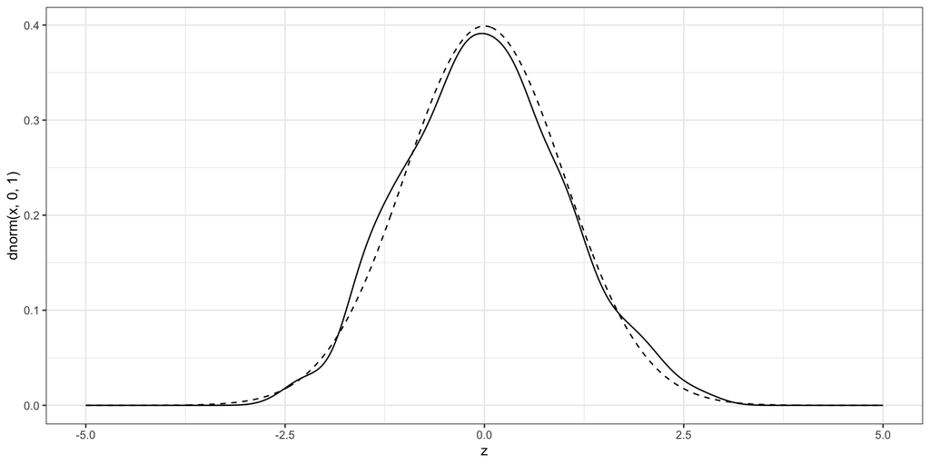

## Not just the binomial…

```r
n_sims <- 1000
output<-data.frame(sums = rep(NA, n_sims))
for(i in 1:1000){
  temp <- rpois(100, 3)
  output$sums[i] <- sum(temp)
}

hist(temp)
```

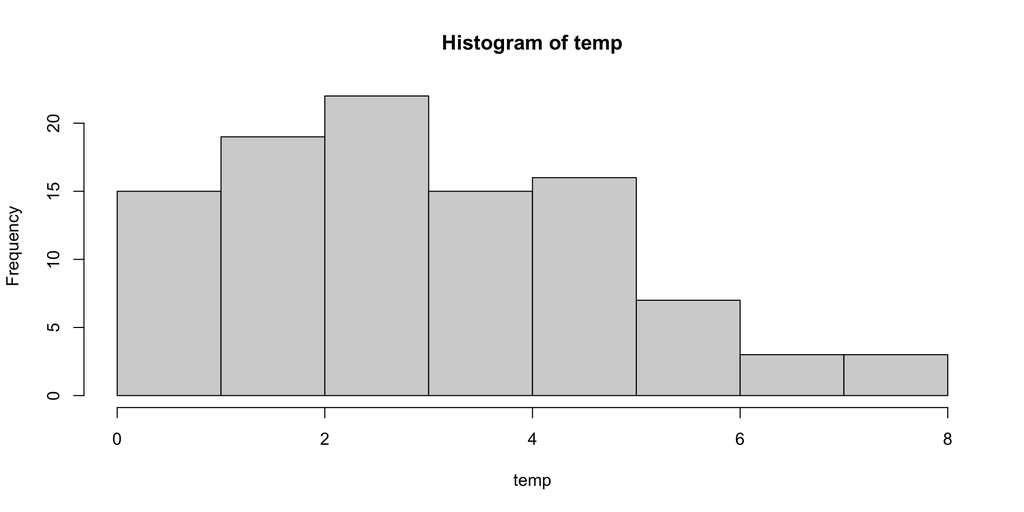

## Sums of random variables ~ N

```r
ggplot(output, aes(x = sums)) + geom_density()
```

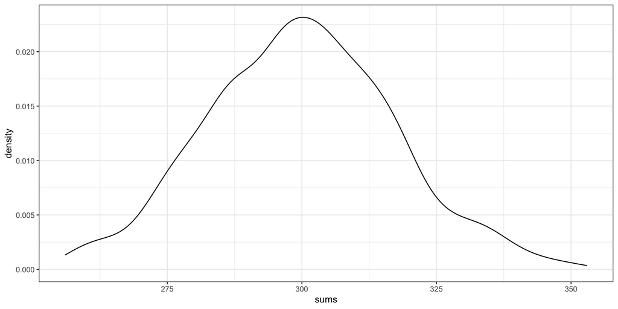

## Again!

```r
output <- output |>
  mutate(z = scale(sums),
         x = seq(-5, 5, length.out = n_sims))
ggplot(output,
       aes(x = z)) +
  geom_density() +
  geom_line(aes(x = x, y = dnorm(x, 0, 1)), lty = 2)
```

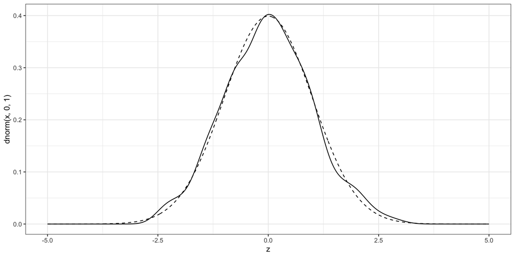

## Getting to know the Normal

- Normal (Gaussian) have two parameters: mean ($\mu$) and standard deviation ($\sigma$)
- These two parameters describe the location and spread of the distribution

```r
xrange<-seq(-7,7,length.out=100)

normals<-data.frame(x = rep(xrange, 4),
                    y = c(dnorm(xrange, 0, 1),
                              dnorm(xrange, 0, 1.5),
                              dnorm(xrange, 0, 2),
                              dnorm(xrange, 0, 2.5)),
                    SD = rep(c("1", "1.5", "2", "2.5"), each = 100))

ggplot(normals, aes(x = x,y = y, color = SD)) +
  geom_line()
```

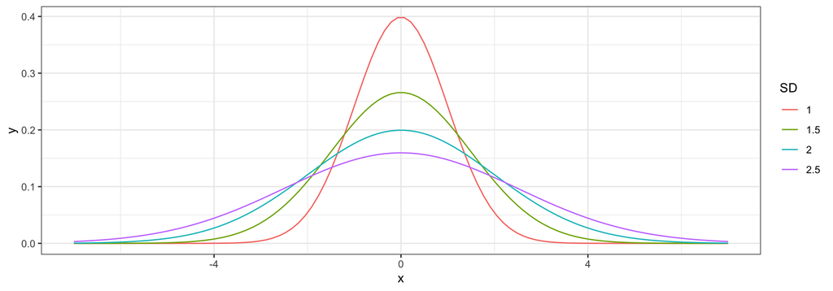

```r
xrange<-seq(-5,5,length.out=100)

normals<-data.frame(x = rep(xrange, 4),
                    y = c(dnorm(xrange, 0, 1),
                              dnorm(xrange, 0.5, 1),
                              dnorm(xrange, 1, 1),
                              dnorm(xrange, 1.5, 1)),
                    Mu = rep(c("1", "1.5", "2", "2.5"), each = 100))

ggplot(normals, aes(x = x,y = y, color = Mu)) +
  geom_line()
```

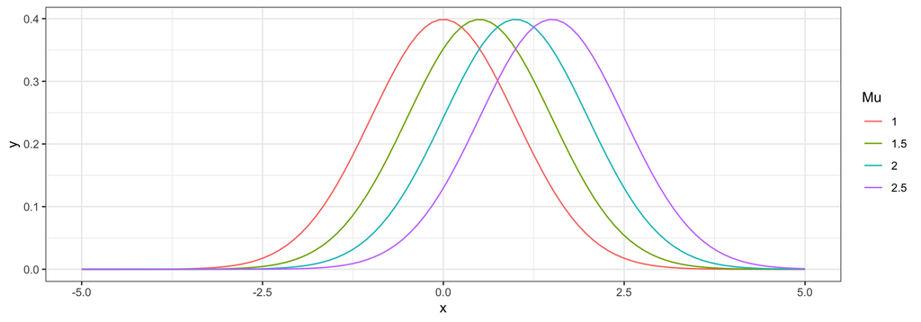